# FinalProject - Group7

Alma Parias, Rafael Muñoz, Beatrice Olivari, Omar Echbiki and Miguel Pérez

19/12/2019

This is our final projct for the subject Data Processes. The topic we chose is **Climate Change**.

## Abstract

### Introduction

We would like to answer this question because Climate Change is a really important issue we have now. The poles are melting, the sea level is growing and the temperature is rising. All of these problems can change the world and the way we live. We think people must be aware of this and try to slow the process.

### Related Work

[Participants in actions against climate change](https://climateaction.unfccc.int/) In this link can be found a map, where you can select a country and see the initiatives. This is done by the United Nations.

[World Climate Summit Madrid](https://www.worldclimatesummit.org/) This year the world Climate Summit has been held in Madrid. Some of the topics were e-mobility, smart cities, sustinable forest and responsible resource extraction. This is a way to concienciate people and think new regulations and ideas.

[Study about the need of more studies to show that Climate Chage is real](https://www.nature.com/articles/s41558-018-0360-1) This study says that some people doesn’t believe in empirical data and that more studies that shows the effects are needed.

[Lichens are a biosensor of climate change](https://www.mdpi.com/1424-2818/11/3/42) The lichens in Antarctica are a natural biosensor to measure the evolution of climate change.

[Food distribution related with climate change](https://esajournals.onlinelibrary.wiley.com/doi/full/10.1002/ecs2.2645) Trophic interactions within food webs affect species distributions, coexistence, and provision of ecosystem services but can be strongly impacted by climatic changes.

For further reading, here are [Some articles about how climate change is affecting the nature](https://www.nature.com/nclimate/research) Some examples about how climate change is affecting the nature and sme examples about why the climate is getting worse.

## Exploratory Data Analysis

In this part the three datasets that we are going to use are going to be presented.

### CO2 emissions

This dataset describes Trends in Atmospheric Carbon Dioxide and it contains data from **1958** to **2018**. [Source](https://datahub.io/anuveyatsu/co2-ppm): The raw dataset has the following features:

- **Date:** the day of the recording in *yy-mm-YYYY* format
- **Average [Parts per million]:** The monthly mean CO2 mole fraction determined from daily averages. If there are missing days concentrated either early or late in the month, the monthly mean is corrected to the middle of the month using the average seasonal cycle. Missing months are denoted by *-99.99*.
- **Interpolated [Parts per million]:** Values from the average column and interpolated values where data are missing. Interpolated values are computed in two steps. First, we compute for each month the average seasonal cycle in a 7-year window around each monthly value. In this way the seasonal cycle is allowed to change slowly over time. We then determine the trend value for each month by removing the seasonal cycle; this result is shown in the trend column. Trend values are linearly interpolated for missing months. The interpolated monthly mean is then the sum of the average seasonal cycle value and the trend value for the missing month.
- **Trend [Parts per million]:** Seasonally corrected.
- **Number.of.Days:** Number of days for the recording: **-1** denotes no data for number of daily averages in the month.

```
{r CO2 data processing, include=FALSE}
```

```
##       Date               Average       Interpolated       Trend
##  Min.   :1958-03-01   Min.   :313.2   Min.   :313.2   Min.   :314.6
##  1st Qu.:1973-07-24   1st Qu.:328.9   1st Qu.:328.9   1st Qu.:329.9
##  Median :1988-09-16   Median :351.6   Median :351.6   Median :352.2
##  Mean   :1988-08-15   Mean   :353.9   Mean   :353.9   Mean   :353.9
##  3rd Qu.:2003-09-08   3rd Qu.:376.0   3rd Qu.:376.0   3rd Qu.:376.5
##  Max.   :2018-09-01   Max.   :411.2   Max.   :411.2   Max.   :409.0
##
##  Number.of.Days       Year
##  Min.   :-1.00   1959   : 12
##  1st Qu.:-1.00   1960   : 12
##  Median :25.00   1961   : 12
##  Mean   :18.52   1962   : 12
##  3rd Qu.:28.00   1963   : 12
##  Max.   :31.00   1965   : 12
##                  (Other):648
```

## Data Preparation

Before proceeding to use the dataset we have to do some preliminary operation:

1. Removing non useful features such as *Decimal.Date* since it is a repetition of Date
2. Converting the Date fields to R Date to be used in the plot, since ggplot2 treats it as a time series and handled differently
3. Removing the outliers, since in Average there are a few observations that have a value of **-99.99** this changes radically the scale of the plot

```r
outlier_values <- boxplot.stats(co2data$Average)$out
outlier_values
```

```
## numeric(0)
```

We also wanted to know which was (in terms of climate change) the ‘worst year’ for our planet? (more polluted year, higher temperature…).

After doing so we get the following data frame:

```r
co2data_year <-  co2data %>%
  group_by(Year) %>%
  summarise(Trend = median(Trend))

head(co2data_year)
```

```
## # A tibble: 6 x 2
##   Year  Trend
##   <fct> <dbl>
## 1 1958   315.
## 2 1959   316.
## 3 1960   317.
## 4 1961   318.
## 5 1962   318.
## 6 1963   319.
```

Now we can plot the results.

To answer this question it is enough to run this simple query using again the dplyr package. This command will return one value which is the date of the highest CO2 level

```r
worst_year <-co2data %>%
  filter(Trend == max(Trend))  %>%
  select(Date)
worst_year
```

```
##         Date
## 1 2018-09-01
```

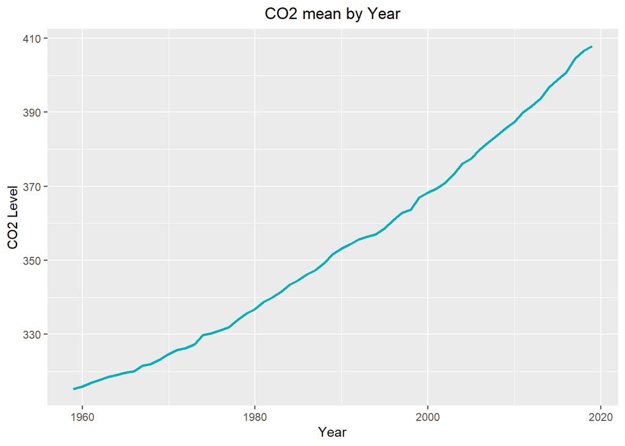

### International comprehensive Ocean-Atmosphere (ICOADS-NOAA)

Dataset description https://rda.ucar.edu/datasets/ds548.0/

The International Comprehensive Ocean-Atmosphere Data Set (ICOADS) is a global ocean marine meteorological and surface ocean dataset. It contains data measurements and visual observation collected by ships, moored and drifting buoys, coastal stations, and other marine and near-surface ocean platforms. Each marine report contains individual observations of meteorological and oceanographic variables, such as sea surface and air temperatures, wind, pressure, humidity, and cloudiness. The coverage is global and sampling density varies depending on date and geographic position relative to shipping routes and ocean observing systems. The dataset (which contains the observations from the year 2010) consists of 76 columns and 100,000 rows, but many of the columns present a lot of missing values (in many cases more than a half of the observations), so that we had to drop many of them.

#### Data processing

Taking into account the general topic of interest, we decided to consider only the features regarding temperature, pressure of water, weather, clouds and waves. However, after analysing the number of NA values into the columns, we realized that most of them weren’t useful because of the high percentage of missing values (sometimes more than a half) so we deleted them. After doing this process, we deleted the remaining NA values, by getting rid of the rows containing them. Eventually, the final dataset was composed by 9 columns and 69,050 rows.

#### Graphs

1. Firstly, we choose to represent the values of the sea_level_pressure in a world map. Lower values of pressure are represented by blue colours, while higher values are represented by yellow and red colours.

[figure not shown]

2. In order to make a comparison between the evolution of temperature during the year in the northern and southern pole, we plotted two bar charts.

[figure not shown]

[output not shown]

[output cut: 88 more lines]

[output not shown]

[figure not shown]

[figure not shown]

### The National Snow and Ice Data Center

The National Snow and Ice Data Center (NSIDC) supports research into our world’s frozen realms: the snow, ice, glaciers, frozen ground, and climate interactions that make up Earth’s cryosphere. NSIDC manages and distributes scientific data, creates tools for data access, supports data users, performs scientific research, and educates the public about the cryosphere.

#### Content

- Year
- Month
- Day
- Extent: unit is 10^6 sq km
- Missing: unit is 10^6 sq km
- Source: Source data product web site: http://nsidc.org/data/nsidc-0051.html
- Hemisphere: North or South

The main problem with this dataset it that measures are taken every 2 days, while the co2 are monthly.

[output not shown]

For this reason, we had to: - Take a look at the possible exising cycles of ice extent during each month - See if we can compress all that information in a few features (like mean and variance or jitter or some statistical feature).

```
## Analysis of Variance Table
##
## Response: Extent
##                             Df Sum Sq Mean Sq   F value    Pr(>F)
## Date                         1   1965    1965  102.7799 < 2.2e-16 ***
## Year                         1  31833   31833 1665.3461 < 2.2e-16 ***
## Month                        1    296     296   15.5032 8.258e-05 ***
## Day                          1   1713    1713   89.5968 < 2.2e-16 ***
## Missing                      1      2       2    0.1213    0.7277
## hemisphere                   1    461     461   24.1423 9.001e-07 ***
## `Global Extent`              1  20617   20617 1078.5827 < 2.2e-16 ***
## `North-South Difference`     1      0       0    0.0000    0.9984
## Residuals                26345 503590      19
## ---
## Signif. codes:  0 '***' 0.001 '**' 0.01 '*' 0.05 '.' 0.1 ' ' 1
```

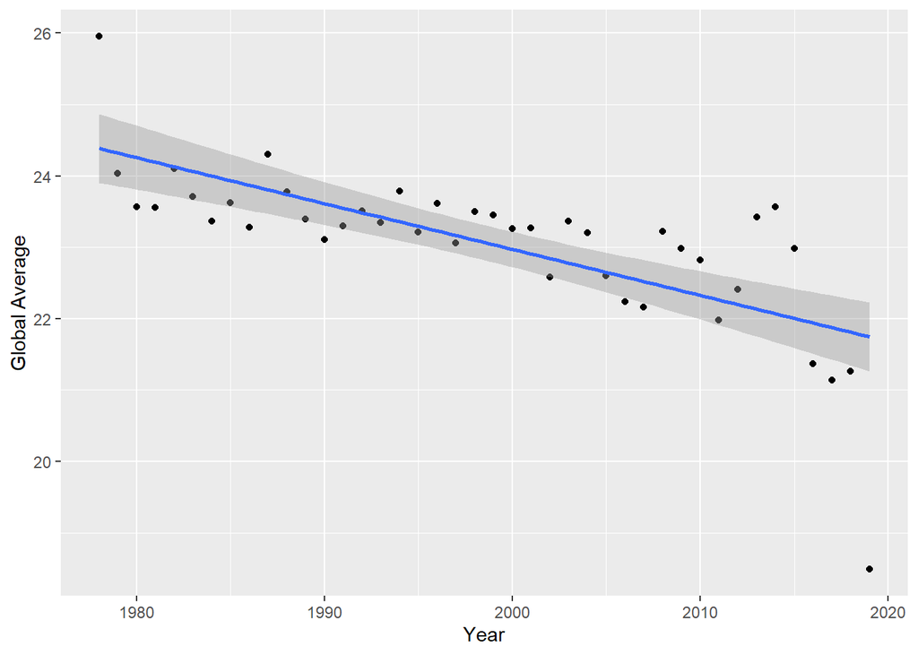

The other thing we did is we provided a different columns for each one of the hemisphere, instead of having 2 rows for each observation: one for northern hemisphere and other for the southern, and added two extra columns: global extent and difference between north and south. This can be done, since all measures are an absolute value (10^6 km squared) and they are additive.

## Methods

To be able to create a model, first we need to have one dataset. In this case, we are only going to use **The National Snow and Ice Data Center** and **CO2**.

We merged all the data via month, and calculated the mean for each month. After that, we proceeded to merge co2 dataset and ice extent dataset. This was an easy task after rearranging the times, but we were careful in the merging, so missing values are completely eliminated from both datasets.

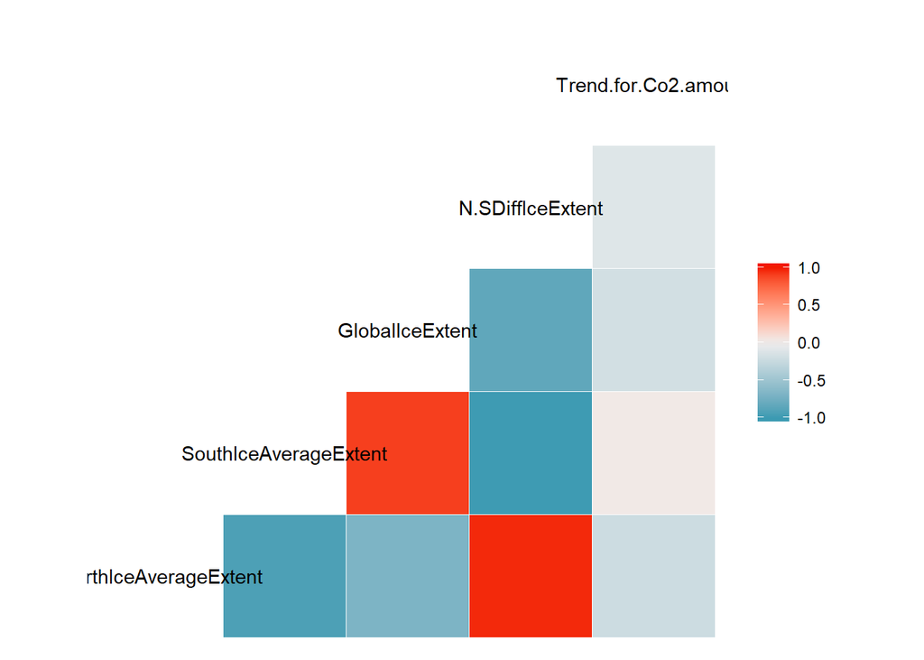

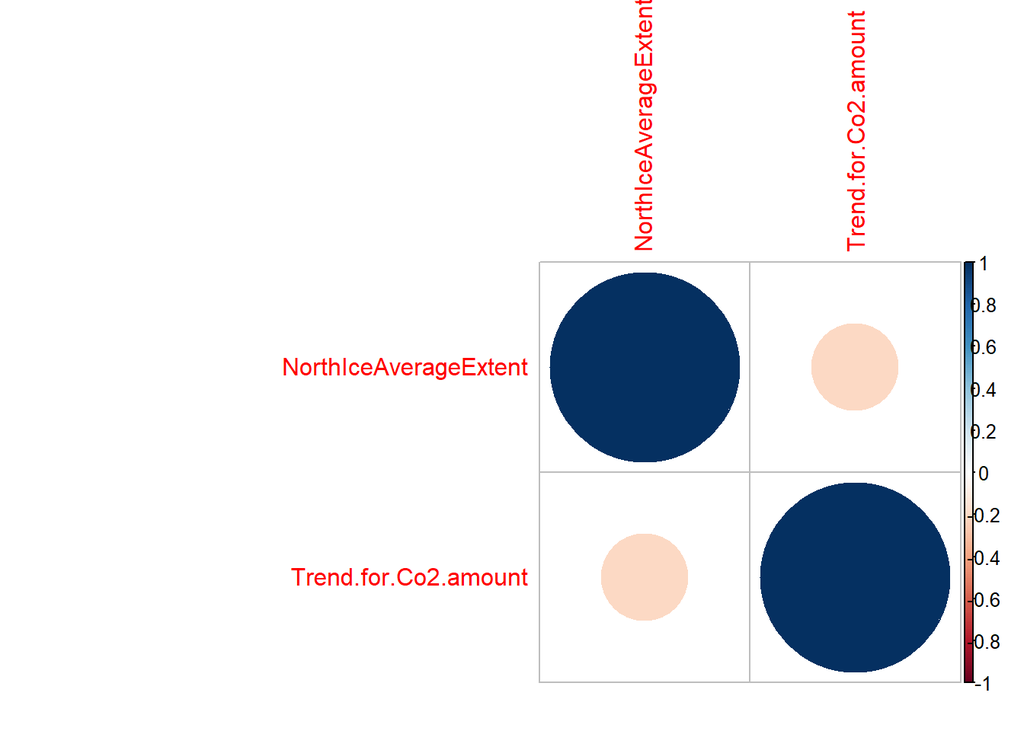

## Discussion and future work

The ICOADS dataset is also temporal, but it is huge. The dataset is in GoogleBigQueries, so we can’t download complete. As future work it will be interesting using RSpark and use the whole dataset to try to improve the predictions with the data af the oceans.